# DATA621 Homework 3

Joseph Simone, Jack Russo, Javern Wilson, Paul Perez

3/22/2020

## Overview

In this homework assignment, we will explore, analyze and model a data set containing information on crime for various neighborhoods of a major city. Each record has a response variable indicating whether or not the crime rate is above the median crime rate (1) or not (0).

Our objective is to build a binary logistic regression model on the training data set to predict whether the neighborhood will be at risk for high crime levels. We will provide classifications and probabilities for the evaluation data set using our binary logistic regression model.

## Data Import and Preview

| zn | indus | chas | nox | rm | age | dis | rad | tax | ptratio | lstat | medv | target |
| --- | --- | --- | --- | --- | --- | --- | --- | --- | --- | --- | --- | --- |
| 0 | 19.58 | 0 | 0.605 | 7.929 | 96.2 | 2.0459 | 5 | 403 | 14.7 | 3.70 | 50.0 | 1 |
| 0 | 19.58 | 1 | 0.871 | 5.403 | 100.0 | 1.3216 | 5 | 403 | 14.7 | 26.82 | 13.4 | 1 |
| 0 | 18.10 | 0 | 0.740 | 6.485 | 100.0 | 1.9784 | 24 | 666 | 20.2 | 18.85 | 15.4 | 1 |
| 30 | 4.93 | 0 | 0.428 | 6.393 | 7.8 | 7.0355 | 6 | 300 | 16.6 | 5.19 | 23.7 | 0 |
| 0 | 2.46 | 0 | 0.488 | 7.155 | 92.2 | 2.7006 | 3 | 193 | 17.8 | 4.82 | 37.9 | 0 |
| 0 | 8.56 | 0 | 0.520 | 6.781 | 71.3 | 2.8561 | 5 | 384 | 20.9 | 7.67 | 26.5 | 0 |

## EDA

### Number of Target Variables

```
##
##   0   1
## 237 229
```

### Dataset Summaries

|  | zn | indus | chas | nox | rm | age |
| --- | --- | --- | --- | --- | --- | --- |
|  | Min. : 0.00 | Min. : 0.460 | Min. :0.00000 | Min. :0.3890 | Min. :3.863 | Min. : 2.90 |
|  | 1st Qu.: 0.00 | 1st Qu.: 5.145 | 1st Qu.:0.00000 | 1st Qu.:0.4480 | 1st Qu.:5.887 | 1st Qu.: 43.88 |
|  | Median : 0.00 | Median : 9.690 | Median :0.00000 | Median :0.5380 | Median :6.210 | Median : 77.15 |
|  | Mean : 11.58 | Mean :11.105 | Mean :0.07082 | Mean :0.5543 | Mean :6.291 | Mean : 68.37 |
|  | 3rd Qu.: 16.25 | 3rd Qu.:18.100 | 3rd Qu.:0.00000 | 3rd Qu.:0.6240 | 3rd Qu.:6.630 | 3rd Qu.: 94.10 |
|  | Max. :100.00 | Max. :27.740 | Max. :1.00000 | Max. :0.8710 | Max. :8.780 | Max. :100.00 |

|  | dis | rad | tax | ptratio | lstat | medv |
| --- | --- | --- | --- | --- | --- | --- |
|  | Min. : 1.130 | Min. : 1.00 | Min. :187.0 | Min. :12.6 | Min. : 1.730 | Min. : 5.00 |
|  | 1st Qu.: 2.101 | 1st Qu.: 4.00 | 1st Qu.:281.0 | 1st Qu.:16.9 | 1st Qu.: 7.043 | 1st Qu.:17.02 |
|  | Median : 3.191 | Median : 5.00 | Median :334.5 | Median :18.9 | Median :11.350 | Median :21.20 |
|  | Mean : 3.796 | Mean : 9.53 | Mean :409.5 | Mean :18.4 | Mean :12.631 | Mean :22.59 |
|  | 3rd Qu.: 5.215 | 3rd Qu.:24.00 | 3rd Qu.:666.0 | 3rd Qu.:20.2 | 3rd Qu.:16.930 | 3rd Qu.:25.00 |
|  | Max. :12.127 | Max. :24.00 | Max. :711.0 | Max. :22.0 | Max. :37.970 | Max. :50.00 |

### Distribution of Predictors

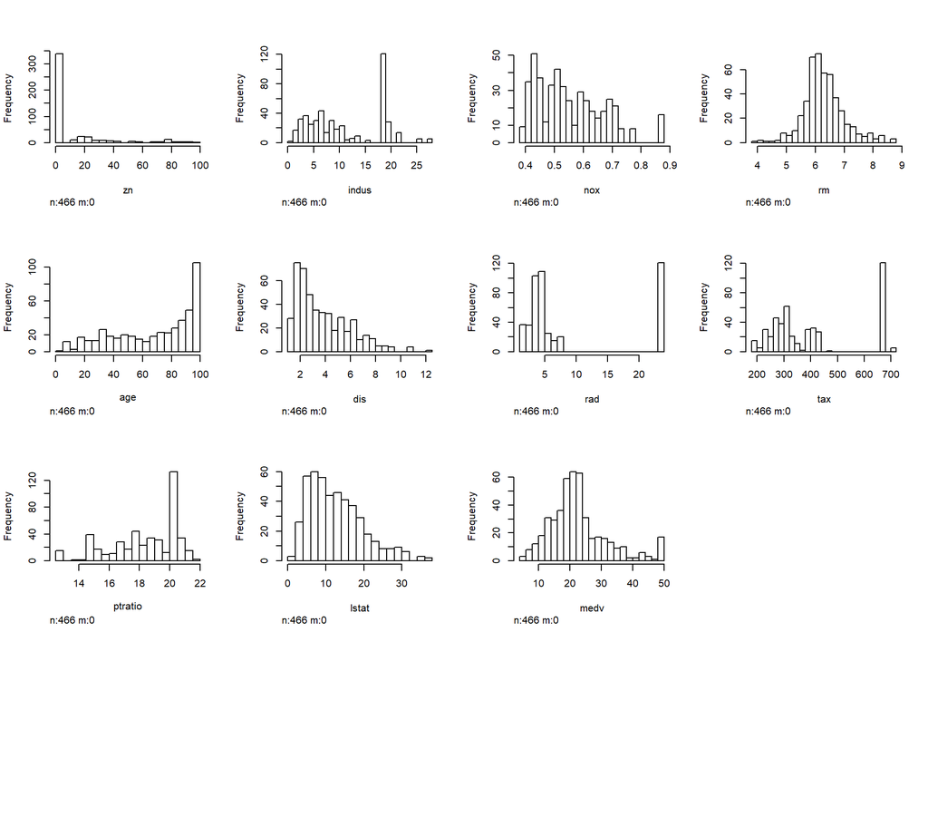

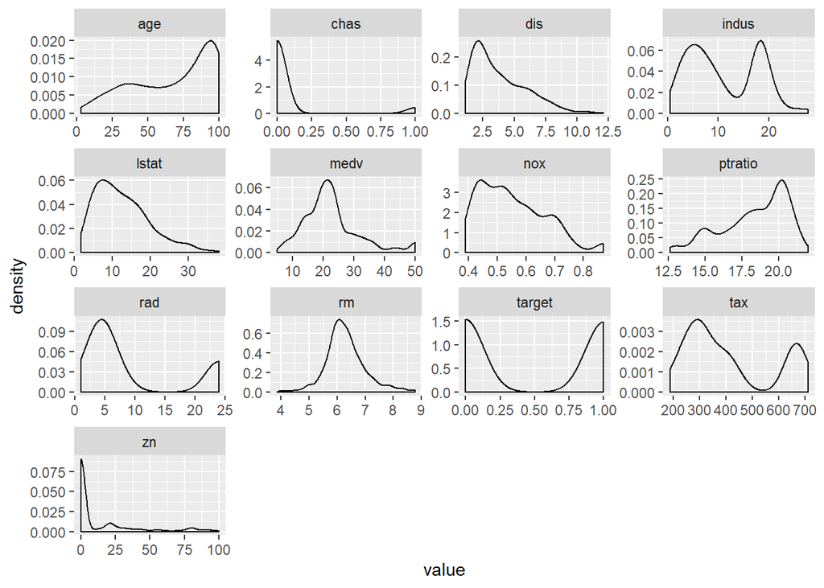

### Boxplot

Of each continuous independent variable with target.

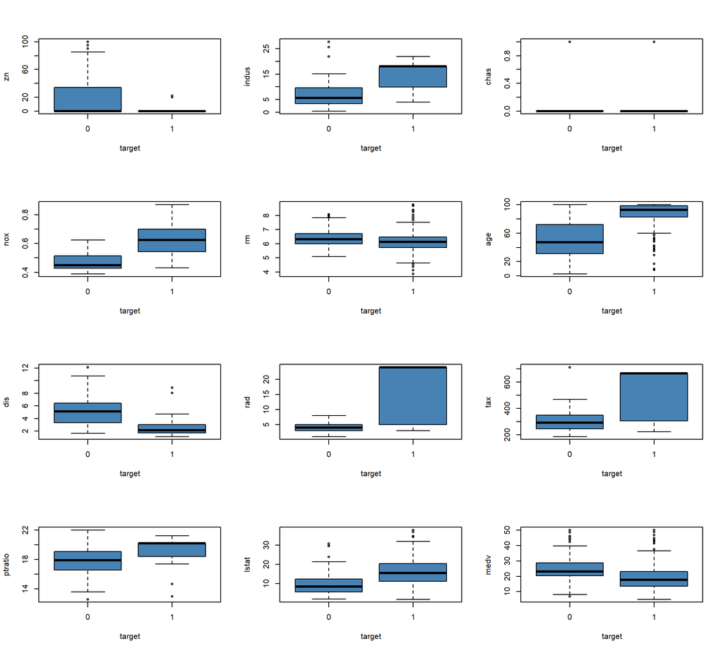

From the above plots, we can infer that the crime rate is above the median when majority of the predictors are high. For instance, have a look at `nox` (nitrogen oxide) and `tax` (property tax).

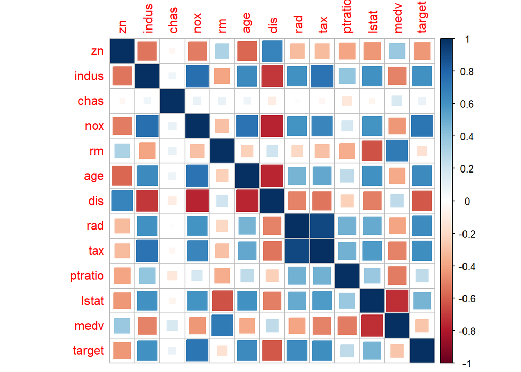

```
##
##  Pearson's product-moment correlation
##
## data:  crime$rad and crime$tax
## t = 46.239, df = 464, p-value < 2.2e-16
## alternative hypothesis: true correlation is not equal to 0
## 95 percent confidence interval:
##  0.8888115 0.9214292
## sample estimates:
##       cor
## 0.9064632
```

## DATA PREPARATION

### Missing Cases

```
## [1] FALSE
```

There does not appear to be missing cases.

### Scale Data

Use scale function to scale all variables to mean and standard devatiotion of target variable.

```
## [1] 0.4914163
```

```
## [1] 0.5004636
```

```
##    target        zn     indus      chas       nox        rm       age       dis
## 0.4914163 0.4914163 0.4914163 0.4914163 0.4914163 0.4914163 0.4914163 0.4914163
##       rad       tax   ptratio     lstat      medv
## 0.4914163 0.4914163 0.4914163 0.4914163 0.4914163
```

```
##    target        zn     indus      chas       nox        rm       age       dis
## 0.5004636 0.5000000 0.5000000 0.5000000 0.5000000 0.5000000 0.5000000 0.5000000
##       rad       tax   ptratio     lstat      medv
## 0.5000000 0.5000000 0.5000000 0.5000000 0.5000000
```

After scaling, the predictor and responce variables posses approximately equal means and standard deviations.

### Sigmoid Function

We will use sigmoid function to scale all variables between zero and one.

The following transformation will map each of the values on to the Logistic curve. This will allow us to construct a linear model on with the scaled data.

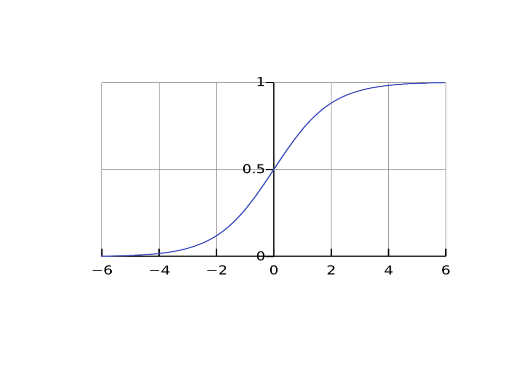

```
##    target        zn     indus      chas       nox        rm       age       dis
## 0.6135460 0.6110187 0.6132653 0.6102377 0.6127209 0.6135238 0.6149403 0.6123702
##       rad       tax   ptratio     lstat      medv
## 0.6119626 0.6125669 0.6153707 0.6125611 0.6124636
```

```
##     target         zn      indus       chas        nox         rm        age
## 0.11563640 0.09545625 0.11283836 0.08254726 0.10869567 0.10784268 0.11746022
##        dis        rad        tax    ptratio      lstat       medv
## 0.10676718 0.10725490 0.11004905 0.11728960 0.10721135 0.10502008
```

After applying the sigmoid function, the predictor and responce variables still retain approximately equal means and standard deviations.

### Transform Predictors

Here all variables were transformed except the target variable. The variables were transformed using Box-Cox. In addition, the variables were scaled, centered and non-zero-variance values were removed (if any).

## BUILD MODELS

### Model 1

#### Build Binomial Regression Using The Scaled Data

```
##
## Call:
## glm(formula = target ~ ., family = binomial, data = ntrain.scaled)
##
## Deviance Residuals:
##     Min       1Q   Median       3Q      Max
## -1.8464  -0.1445  -0.0017   0.0029   3.4665
##
## Coefficients:
##             Estimate Std. Error z value Pr(>|z|)
## (Intercept) -11.1603     1.8624  -5.993 2.07e-09 ***
## zn           -3.0816     1.6195  -1.903  0.05706 .
## indus        -0.8847     0.6520  -1.357  0.17485
## chas          0.4678     0.3880   1.205  0.22803
## nox          11.4619     1.8507   6.193 5.90e-10 ***
## rm           -0.8282     1.0190  -0.813  0.41637
## age           1.9366     0.7825   2.475  0.01333 *
## dis           3.1126     0.9704   3.208  0.00134 **
## rad          11.5760     2.8343   4.084 4.42e-05 ***
## tax          -2.0724     0.9922  -2.089  0.03674 *
## ptratio       1.7687     0.5564   3.179  0.00148 **
## lstat         0.6515     0.7677   0.849  0.39608
## medv          3.3415     1.2620   2.648  0.00810 **
## ---
## Signif. codes:  0 '***' 0.001 '**' 0.01 '*' 0.05 '.' 0.1 ' ' 1
##
## (Dispersion parameter for binomial family taken to be 1)
##
##     Null deviance: 645.88  on 465  degrees of freedom
## Residual deviance: 192.05  on 453  degrees of freedom
## AIC: 218.05
##
## Number of Fisher Scoring iterations: 9
```

```
##
## Call:
## glm(formula = target ~ zn + nox + age + dis + rad + tax + ptratio +
##     medv, family = binomial, data = ntrain.scaled)
##
## Deviance Residuals:
##     Min       1Q   Median       3Q      Max
## -1.8295  -0.1752  -0.0021   0.0032   3.4191
##
## Coefficients:
##             Estimate Std. Error z value Pr(>|z|)
## (Intercept)  -9.7770     1.5871  -6.160 7.26e-10 ***
## zn           -3.2079     1.4962  -2.144  0.03203 *
## nox           9.9885     1.5584   6.410 1.46e-10 ***
## age           1.8664     0.6203   3.009  0.00262 **
## dis           2.7597     0.9020   3.060  0.00222 **
## rad          12.5965     2.6021   4.841 1.29e-06 ***
## tax          -2.6045     0.8908  -2.924  0.00346 **
## ptratio       1.4219     0.4894   2.905  0.00367 **
## medv          2.0415     0.6550   3.117  0.00183 **
## ---
## Signif. codes:  0 '***' 0.001 '**' 0.01 '*' 0.05 '.' 0.1 ' ' 1
##
## (Dispersion parameter for binomial family taken to be 1)
##
##     Null deviance: 645.88  on 465  degrees of freedom
## Residual deviance: 197.32  on 457  degrees of freedom
## AIC: 215.32
##
## Number of Fisher Scoring iterations: 9
```

After using stepAIC method, ‘stepAIC’ function, we are now left with eight independent variables which also resulted in having the minimum AIC value so far.

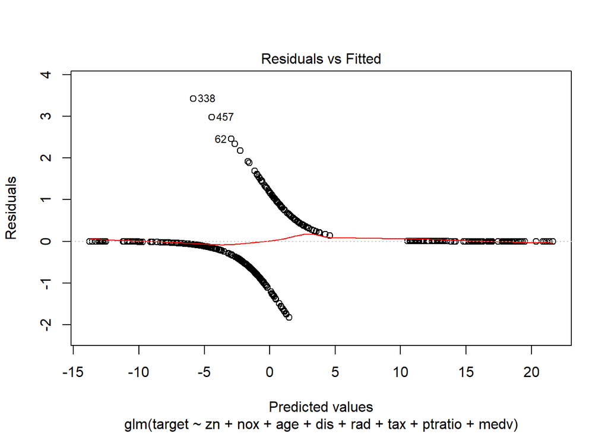

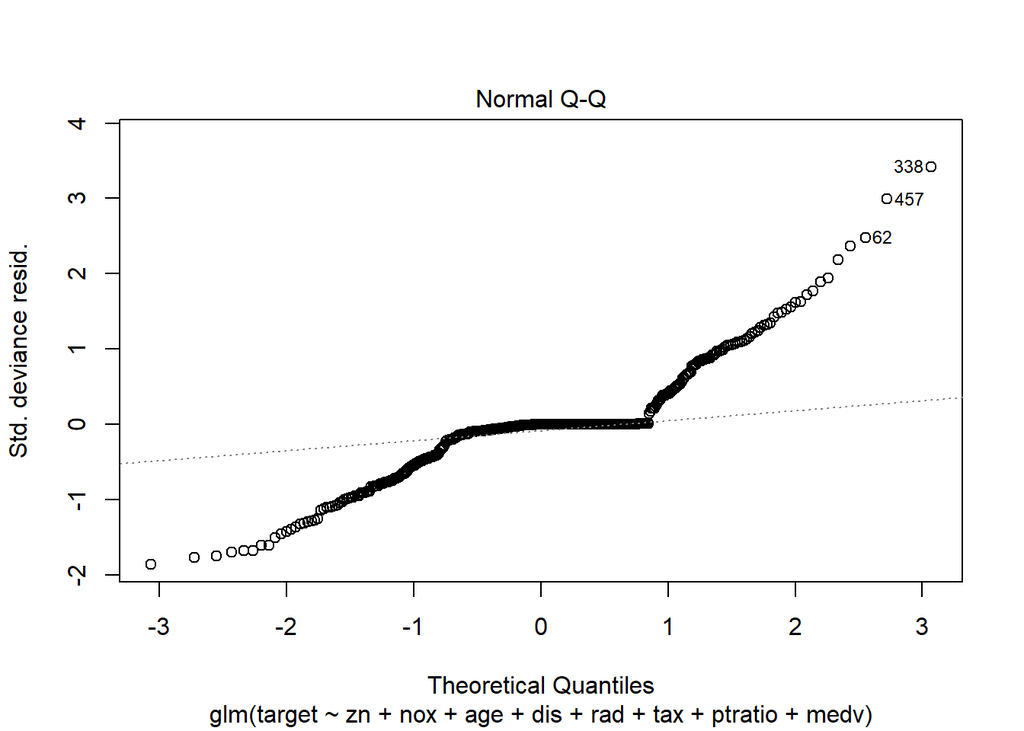

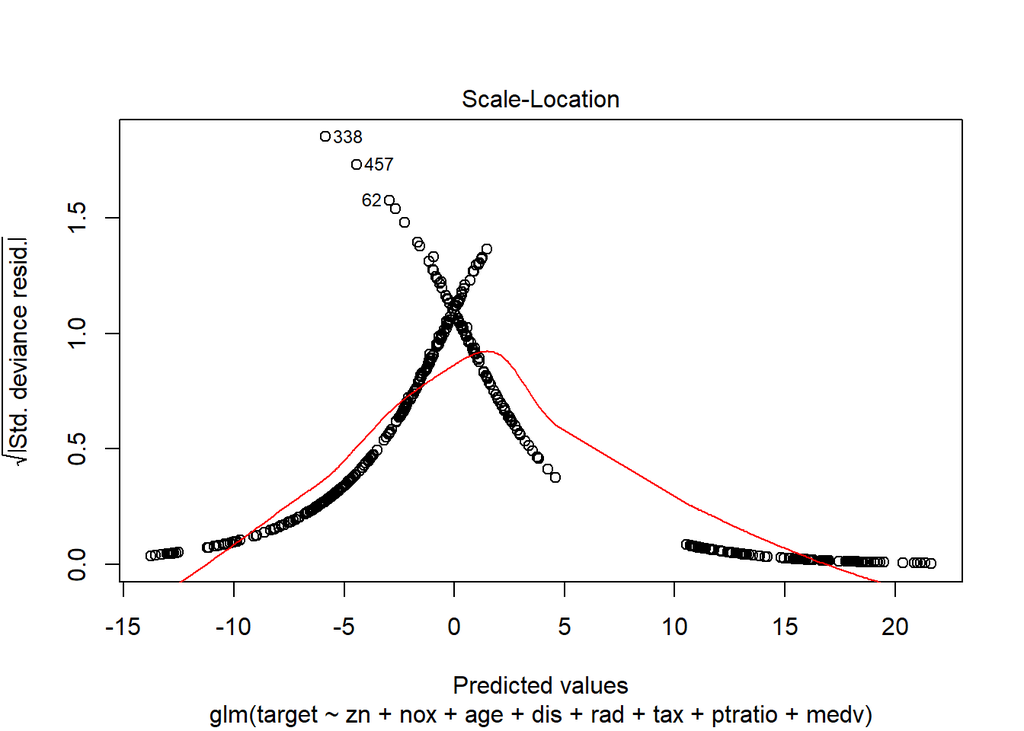

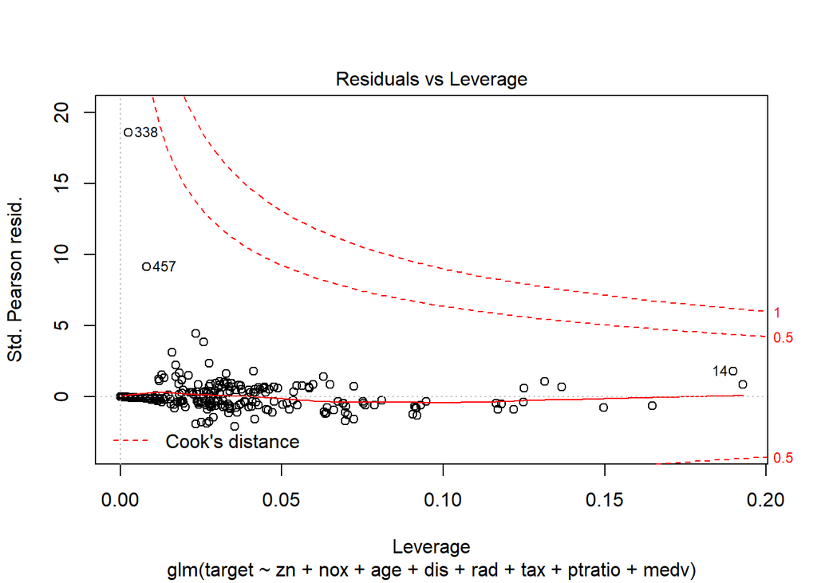

```
##       zn      nox      age      dis      rad      tax  ptratio     medv
## 1.789037 3.172660 1.701974 3.595939 1.697110 1.754274 1.865085 2.193689
```

### Model 2

#### Build Linear Regression Using the Sigmoid Scaled Data.

```
##
## Call:
## lm(formula = target ~ nox + age + rad + medv, data = ntrain.scaled.sigmoid)
##
## Residuals:
##       Min        1Q    Median        3Q       Max
## -0.134511 -0.042567 -0.009906  0.027400  0.208979
##
## Coefficients:
##             Estimate Std. Error t value Pr(>|t|)
## (Intercept) -0.08854    0.04178  -2.120 0.034580 *
## nox          0.52443    0.05396   9.718  < 2e-16 ***
## age          0.16209    0.04349   3.727 0.000218 ***
## rad          0.32503    0.04035   8.056 6.83e-15 ***
## medv         0.13418    0.03697   3.629 0.000316 ***
## ---
## Signif. codes:  0 '***' 0.001 '**' 0.01 '*' 0.05 '.' 0.1 ' ' 1
##
## Residual standard error: 0.07138 on 461 degrees of freedom
## Multiple R-squared:  0.6223, Adjusted R-squared:  0.619
## F-statistic: 189.9 on 4 and 461 DF,  p-value: < 2.2e-16
```

Using the sigmoid scaled data in a linear model has further contrained the relevant predictor variables and minimized the intercept (when compared to the binomial model). This suggests these adjusted variables contain most of the relevant information about this system.

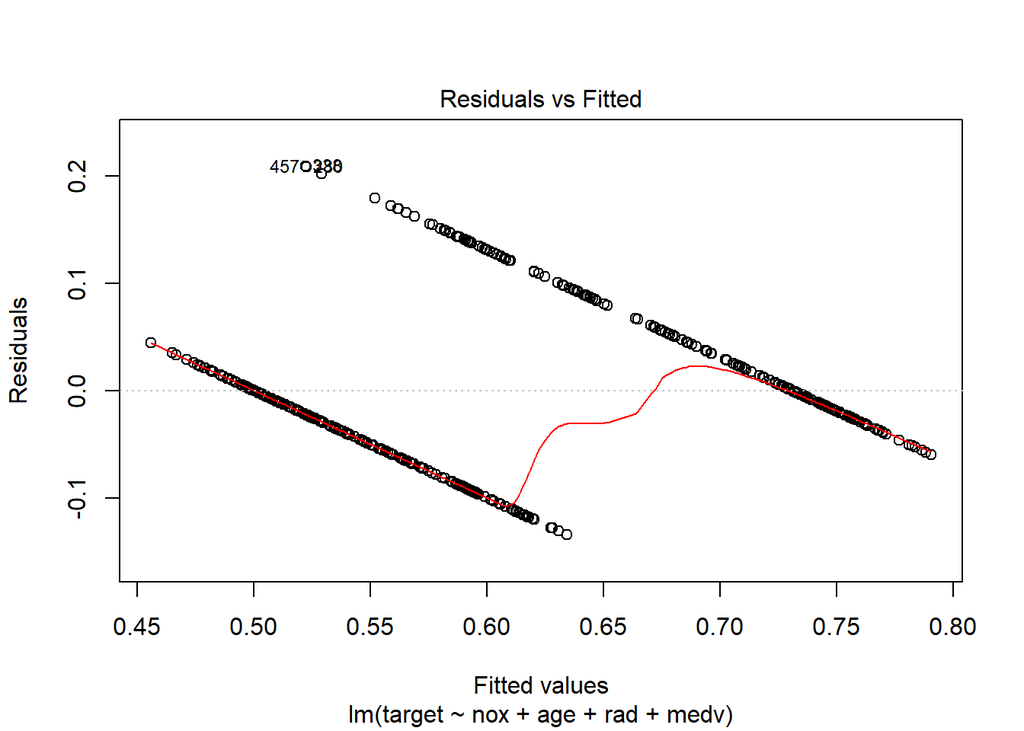

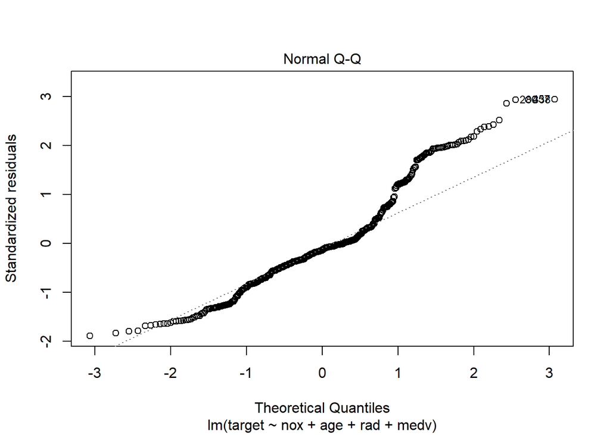

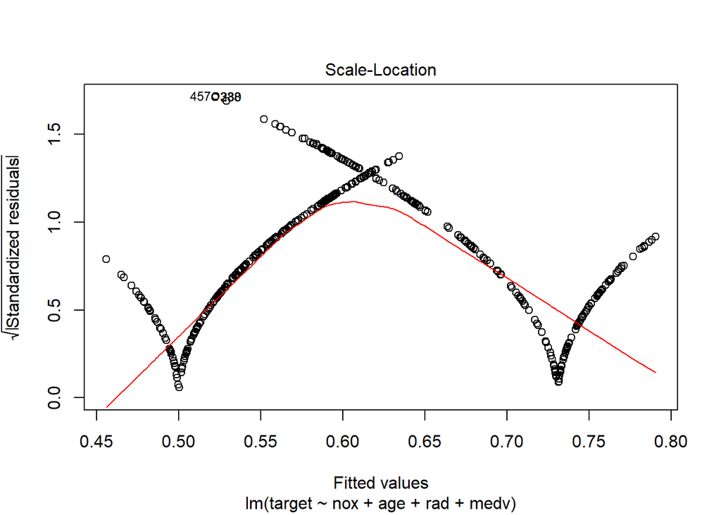

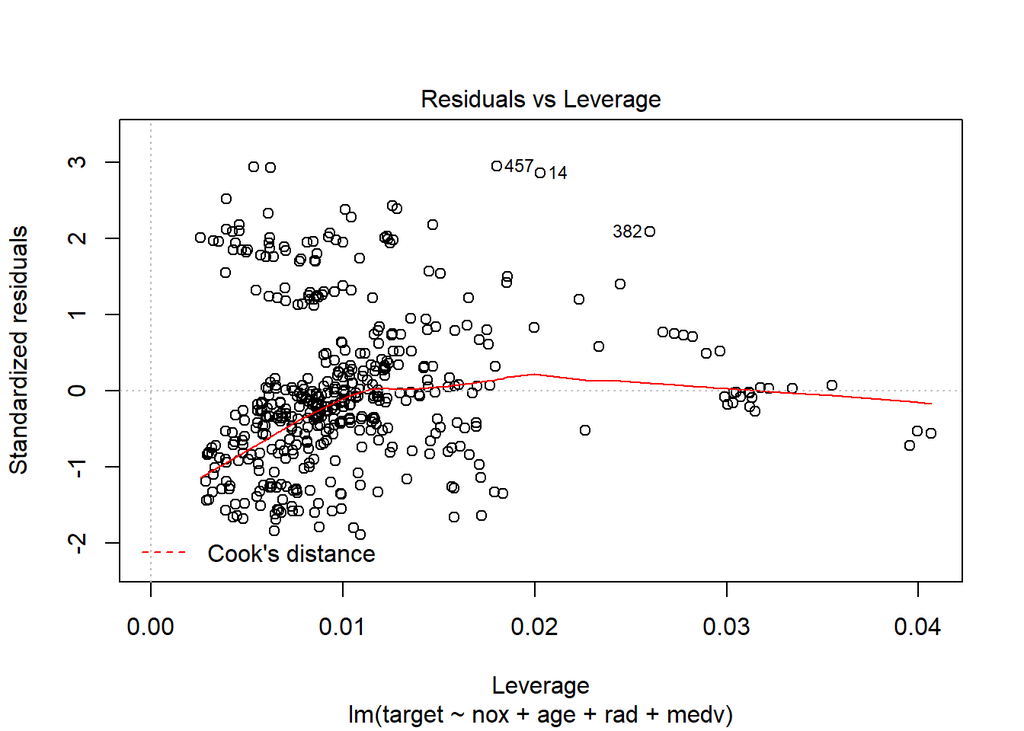

```
##      nox      age      rad     medv
## 3.140318 2.382030 1.709335 1.376141
```

### Model 3

#### Build Linear Regression Using transformed Predictors.

```
##
## Call:
## glm(formula = target ~ ., family = binomial, data = crime_trans)
##
## Deviance Residuals:
##     Min       1Q   Median       3Q      Max
## -1.9381  -0.1116  -0.0010   0.1137   3.4325
##
## Coefficients:
##              Estimate Std. Error z value Pr(>|z|)
## (Intercept) -0.082410   0.316075  -0.261 0.794301
## zn          -0.519732   0.627379  -0.828 0.407433
## indus       -0.003522   0.379970  -0.009 0.992603
## chas         0.242925   0.195625   1.242 0.214316
## nox          4.889837   0.772981   6.326 2.52e-10 ***
## rm          -0.375393   0.453263  -0.828 0.407556
## age          1.154904   0.373442   3.093 0.001984 **
## dis          1.834862   0.469904   3.905 9.43e-05 ***
## rad          2.728346   0.634460   4.300 1.71e-05 ***
## tax         -0.322880   0.408076  -0.791 0.428812
## ptratio      0.979115   0.277238   3.532 0.000413 ***
## lstat       -0.048931   0.424222  -0.115 0.908173
## medv         1.845058   0.642208   2.873 0.004066 **
## ---
## Signif. codes:  0 '***' 0.001 '**' 0.01 '*' 0.05 '.' 0.1 ' ' 1
##
## (Dispersion parameter for binomial family taken to be 1)
##
##     Null deviance: 645.88  on 465  degrees of freedom
## Residual deviance: 196.79  on 453  degrees of freedom
## AIC: 222.79
##
## Number of Fisher Scoring iterations: 8
```

```
##
## Call:
## glm(formula = target ~ chas + nox + age + dis + rad + ptratio +
##     medv, family = binomial, data = crime_trans)
##
## Deviance Residuals:
##     Min       1Q   Median       3Q      Max
## -1.9253  -0.1524  -0.0029   0.1179   3.3556
##
## Coefficients:
##             Estimate Std. Error z value Pr(>|z|)
## (Intercept)   0.1509     0.2265   0.666  0.50533
## chas          0.3094     0.1779   1.739  0.08200 .
## nox           4.8640     0.7230   6.728 1.73e-11 ***
## age           1.0055     0.3060   3.286  0.00102 **
## dis           1.8161     0.4323   4.201 2.66e-05 ***
## rad           2.2998     0.4433   5.188 2.12e-07 ***
## ptratio       0.9617     0.2432   3.954 7.67e-05 ***
## medv          1.5353     0.3609   4.254 2.10e-05 ***
## ---
## Signif. codes:  0 '***' 0.001 '**' 0.01 '*' 0.05 '.' 0.1 ' ' 1
##
## (Dispersion parameter for binomial family taken to be 1)
##
##     Null deviance: 645.88  on 465  degrees of freedom
## Residual deviance: 199.53  on 458  degrees of freedom
## AIC: 215.53
##
## Number of Fisher Scoring iterations: 8
```

```
##     chas      nox      age      dis      rad  ptratio     medv
## 1.114122 3.738991 1.862143 3.338080 1.113786 1.889139 2.520938
```

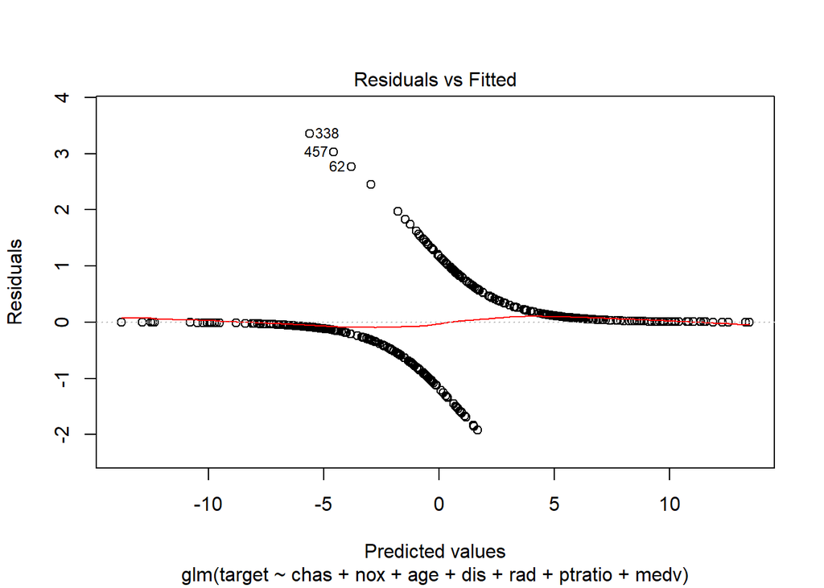

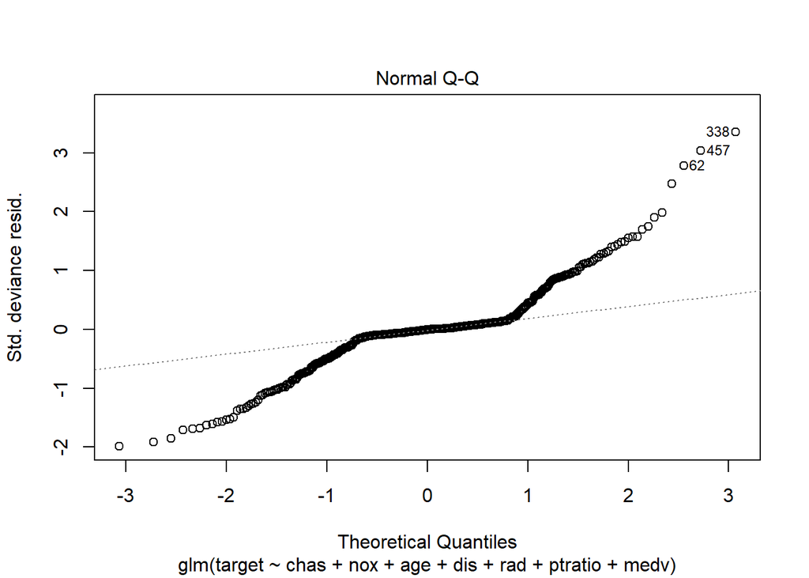

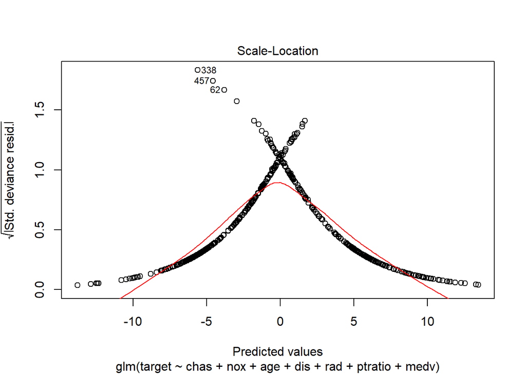

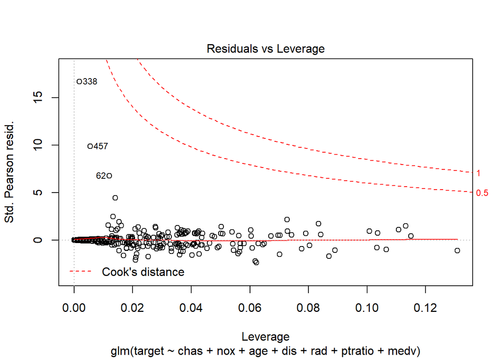

### Model 4

#### Build Generalized Linear Regression Using Sigmoid Scaled Data.

```
##
## Call:
## glm(formula = target ~ ., family = binomial, data = ntrain.scaled.sigmoid2)
##
## Deviance Residuals:
##     Min       1Q   Median       3Q      Max
## -1.8536  -0.1490  -0.0032   0.0128   3.4196
##
## Coefficients:
##             Estimate Std. Error z value Pr(>|z|)
## (Intercept)  -73.414     12.477  -5.884 4.00e-09 ***
## zn           -10.849      6.394  -1.697 0.089724 .
## indus         -3.328      3.023  -1.101 0.270913
## chas           2.711      2.353   1.152 0.249269
## nox           49.003      7.861   6.234 4.55e-10 ***
## rm            -4.482      4.403  -1.018 0.308709
## age            8.887      3.337   2.664 0.007732 **
## dis           15.312      4.424   3.461 0.000537 ***
## rad           45.586     11.386   4.004 6.24e-05 ***
## tax           -7.362      4.204  -1.751 0.079923 .
## ptratio        7.755      2.445   3.172 0.001512 **
## lstat          2.348      3.636   0.646 0.518439
## medv          16.961      5.923   2.863 0.004192 **
## ---
## Signif. codes:  0 '***' 0.001 '**' 0.01 '*' 0.05 '.' 0.1 ' ' 1
##
## (Dispersion parameter for binomial family taken to be 1)
##
##     Null deviance: 645.88  on 465  degrees of freedom
## Residual deviance: 195.93  on 453  degrees of freedom
## AIC: 221.93
##
## Number of Fisher Scoring iterations: 9
```

```
##
## Call:
## glm(formula = target ~ zn + nox + age + dis + rad + tax + ptratio +
##     medv, family = binomial, data = ntrain.scaled.sigmoid2)
##
## Deviance Residuals:
##     Min       1Q   Median       3Q      Max
## -1.7611  -0.1632  -0.0036   0.0080   3.3806
##
## Coefficients:
##             Estimate Std. Error z value Pr(>|z|)
## (Intercept)  -64.719     10.770  -6.009 1.87e-09 ***
## zn           -11.852      5.947  -1.993  0.04627 *
## nox           43.260      6.654   6.502 7.95e-11 ***
## age            8.042      2.684   2.996  0.00273 **
## dis           13.442      4.135   3.251  0.00115 **
## rad           49.279     10.579   4.658 3.19e-06 ***
## tax           -9.616      3.811  -2.523  0.01162 *
## ptratio        6.000      2.139   2.806  0.00502 **
## medv          10.007      3.292   3.040  0.00236 **
## ---
## Signif. codes:  0 '***' 0.001 '**' 0.01 '*' 0.05 '.' 0.1 ' ' 1
##
## (Dispersion parameter for binomial family taken to be 1)
##
##     Null deviance: 645.88  on 465  degrees of freedom
## Residual deviance: 200.56  on 457  degrees of freedom
## AIC: 218.56
##
## Number of Fisher Scoring iterations: 8
```

```
##       zn      nox      age      dis      rad      tax  ptratio     medv
## 1.612196 3.354050 1.746804 3.611908 1.709746 1.875620 1.983801 2.466023
```

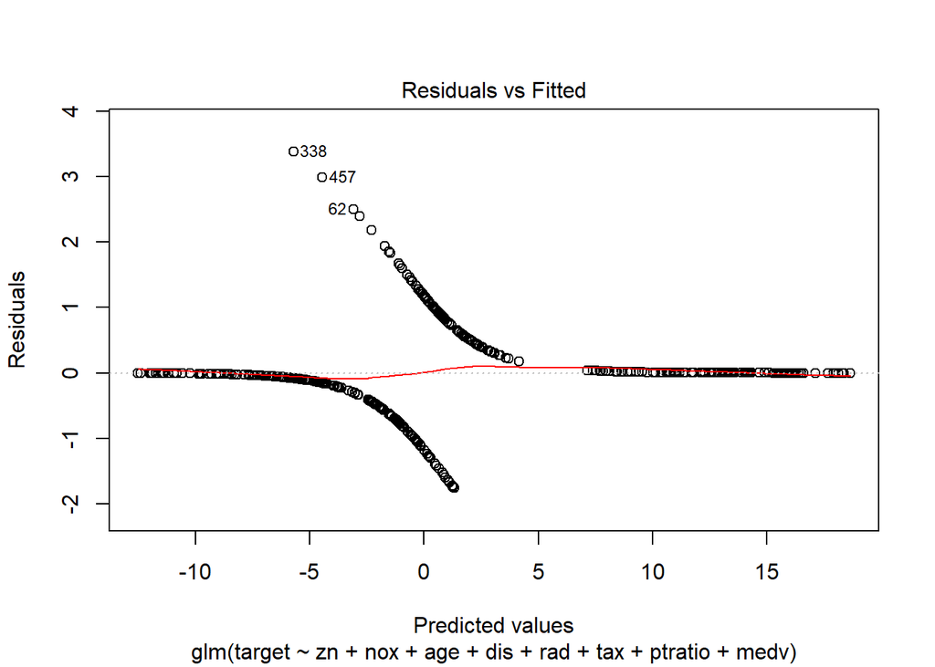

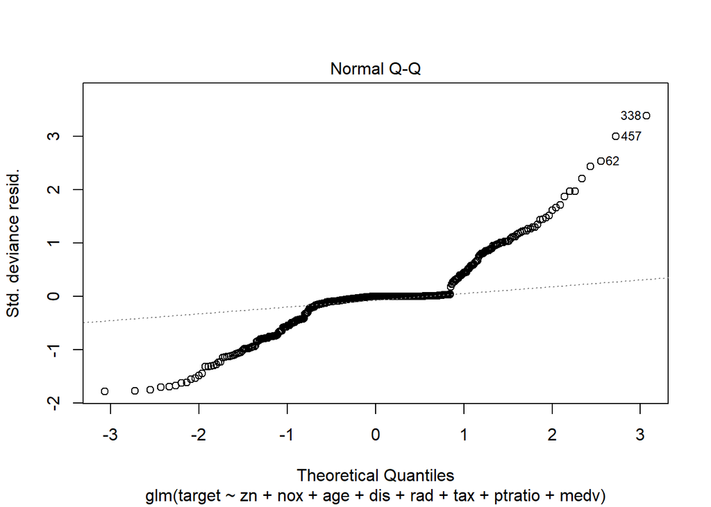

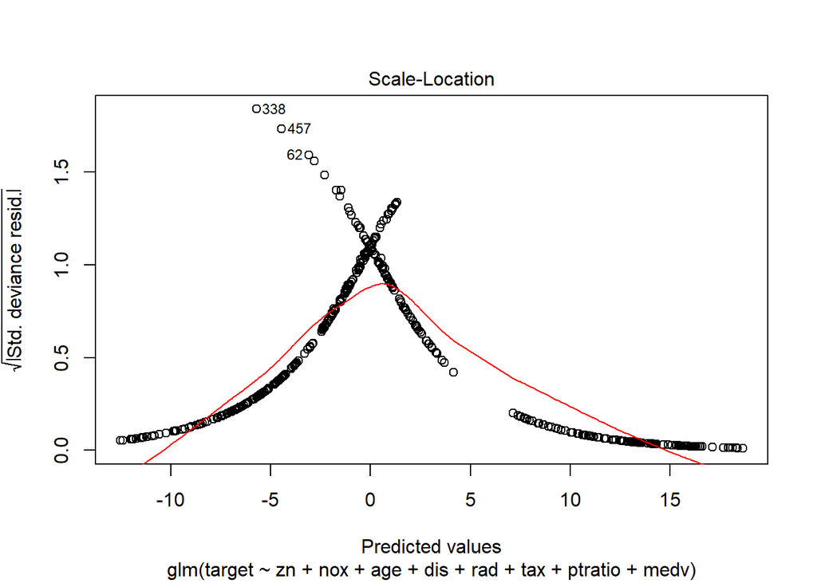

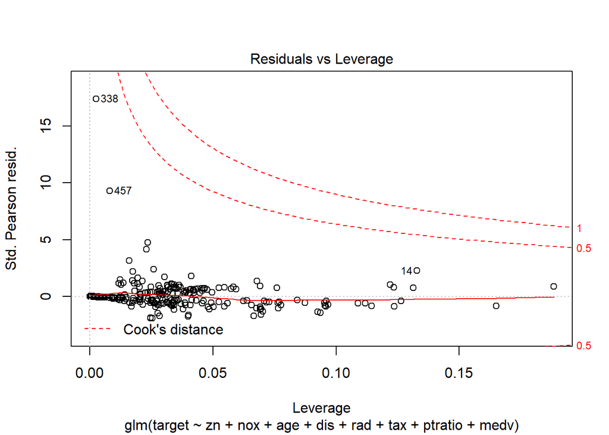

ANOVA

|  | Df | Deviance | Resid. Df | Resid. Dev | Pr(>Chi) |
| --- | --- | --- | --- | --- | --- |
| NULL | NA | NA | 465 | 645.8758 | NA |
| zn | 1 | 127.4113745 | 464 | 518.4645 | 1.509953e-29 |
| nox | 1 | 230.1773605 | 463 | 288.2871 | 5.453349e-52 |
| age | 1 | 0.7674724 | 462 | 287.5196 | 3.810001e-01 |
| dis | 1 | 4.2955034 | 461 | 283.2241 | 3.821328e-02 |
| rad | 1 | 55.9528195 | 460 | 227.2713 | 7.423120e-14 |
| tax | 1 | 15.9164071 | 459 | 211.3549 | 6.620234e-05 |
| ptratio | 1 | 2.7064150 | 458 | 208.6485 | 9.994537e-02 |
| medv | 1 | 11.3256212 | 457 | 197.3229 | 7.644495e-04 |

|  | Df | Deviance | Resid. Df | Resid. Dev | Pr(>Chi) |
| --- | --- | --- | --- | --- | --- |
| NULL | NA | NA | 465 | 645.8758 | NA |
| chas | 1 | 3.0161791 | 464 | 642.8596 | 8.243748e-02 |
| nox | 1 | 354.5265503 | 463 | 288.3331 | 4.379625e-79 |
| age | 1 | 0.6187533 | 462 | 287.7143 | 4.315110e-01 |
| dis | 1 | 6.4008943 | 461 | 281.3134 | 1.140629e-02 |
| rad | 1 | 56.0764096 | 460 | 225.2370 | 6.970852e-14 |
| ptratio | 1 | 2.7057145 | 459 | 222.5313 | 9.998928e-02 |
| medv | 1 | 23.0004363 | 458 | 199.5309 | 1.619646e-06 |

|  | Df | Deviance | Resid. Df | Resid. Dev | Pr(>Chi) |
| --- | --- | --- | --- | --- | --- |
| NULL | NA | NA | 465 | 645.8758 | NA |
| zn | 1 | 126.4851188 | 464 | 519.3907 | 2.408006e-29 |
| nox | 1 | 230.0913156 | 463 | 289.2994 | 5.694141e-52 |
| age | 1 | 0.6514698 | 462 | 288.6479 | 4.195877e-01 |
| dis | 1 | 4.9941452 | 461 | 283.6538 | 2.543321e-02 |
| rad | 1 | 56.9159054 | 460 | 226.7379 | 4.548521e-14 |
| tax | 1 | 13.4624292 | 459 | 213.2754 | 2.433884e-04 |
| ptratio | 1 | 2.1953195 | 458 | 211.0801 | 1.384305e-01 |
| medv | 1 | 10.5163226 | 457 | 200.5638 | 1.183247e-03 |

ANOVA (Comparing the other 3 models)

|  | Resid. Df | Resid. Dev | Df | Deviance | Pr(>Chi) |
| --- | --- | --- | --- | --- | --- |
| 1 | 457 | 197.3229 | NA | NA | NA |
| 2 | 458 | 199.5309 | -1 | -2.208036 | 0.1372933 |
| 3 | 457 | 200.5638 | 1 | -1.032911 | NA |

**Model one** does seem to perform better than the other three models.

## SELECT MODELS

```
##            Actual
## Predictions   0   1
##           0 218  22
##           1  19 207
```

### Metrics

#### ACCURACY

$$\large \text{Accuracy} = \large \frac{TP+TN}{TP+FP+TN+FN}$$

#### CLASSIFICATION ERROR RATE

The Classification Error Rate calculates the number of incorrect predictions out of the total number of predictions in the dataset.

$$\large \text{Classification Error Rate} = \large \frac{FP+FN}{TP+FP+TN+FN}$$

#### PRECISION

This is the positive value or the fraction of the positive predictions that are actually positive.

$$\large \text{Precision} = \large \frac{TP}{TP+FP}$$

#### SENSITIVITY

The sensitivity is sometimes considered the true positive rate since it measures the accuracy in the event population.

$$\large \text{Sensitivity} = \large \frac{TP}{TP+FN}$$

#### SPECIFICITY

This is the true negatitive rate or the proportion of negatives that are correctly identified.

$$\large \text{Specificity} = \large \frac{TN}{TN+FP}$$

#### F1 SCORE OF PREDICTIONS

The F1 Score of Predictions measures the test’s accuracy, on a scale of 0 to 1 where a value of 1 is the most accurate and the value of 0 is the least accurate.

$$\large \text{F1 Score} = \large \frac{2 * Precision*Sensitivity}{Precision + Sensitivity}$$

##### F1 SCORE BOUNDS

```
## [1] 0
```

```
## [1] 1
```

```
##      Min.   1st Qu.    Median      Mean   3rd Qu.      Max.
## 0.0003659 0.1862145 0.3305517 0.3905637 0.6041177 0.9905229
```

#### ROC CURVE

Shows how the true positive rate against the false positive rate at various threshold settings. The AUC (Area Under Curve) tells how much model is capable of distinguishing between classes. Higher the AUC is better, that is, how well the model is at predicting 0s as 0s and 1s as 1s.

Creating an ROC Function

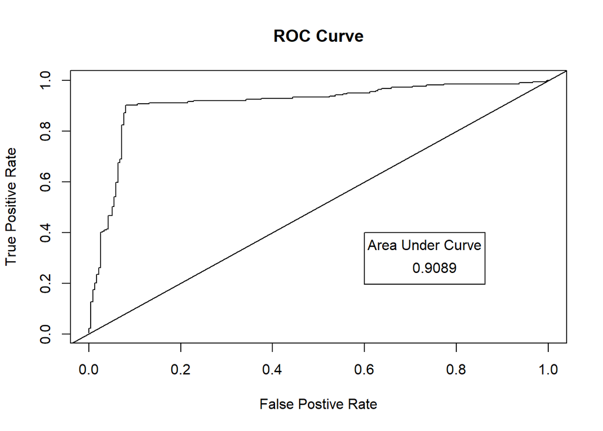

[output not shown]

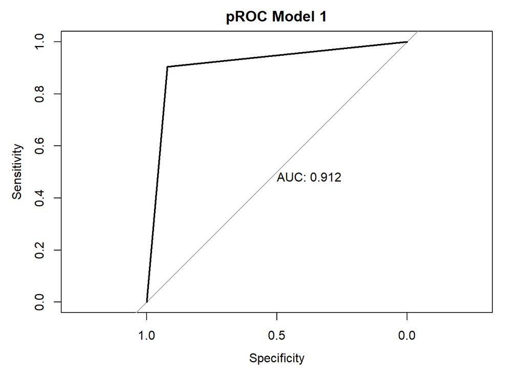

#### RESULTS

Listed below are the results of metrics done for the classification model that was chosen (Model 1).

| Metric | Score |
| --- | --- |
| Accuracy | 0.912 |
| Classification Error Rate | 0.088 |
| Precision | 0.9159 |
| Sensitivity | 0.9039 |
| Specificity | 0.9198 |
| F1 Score | 0.9099 |

#### CONFUSION MATRIX

```
## Confusion Matrix and Statistics
##
##           Reference
## Prediction   0   1
##          0 218  19
##          1  22 207
##
##                Accuracy : 0.912
##                  95% CI : (0.8825, 0.9361)
##     No Information Rate : 0.515
##     P-Value [Acc > NIR] : <2e-16
##
##                   Kappa : 0.8239
##
##  Mcnemar's Test P-Value : 0.7548
##
##             Sensitivity : 0.9159
##             Specificity : 0.9083
##          Pos Pred Value : 0.9039
##          Neg Pred Value : 0.9198
##              Prevalence : 0.4850
##          Detection Rate : 0.4442
##    Detection Prevalence : 0.4914
##       Balanced Accuracy : 0.9121
##
##        'Positive' Class : 1
##
```

Compared with the custom functions used, the results are swapped.

#### Predict on Test Data –>

[Results](https://github.com/ChefPaul/data621/blob/master/Assignment%2003/Pred_Eval.csv)

#### Appendix –>

Find Source Code on [GITHUB](https://github.com/ChefPaul/data621/blob/master/Assignment%2003/DATA621_Project3.Rmd)